# Cyclistic_Report

Akintunde Akinniyi

2022-06-24

## Introduction

In this analysis, i am assuming the position of a junior data analyst working in the marketing analyst team at Cyclistic, a bike-share company in Chicago. The task is to use the previous year’s rider data to investigate how casual riders and annual members use cyclistic bike differently in a bid to come up with recommendations for the company on how to encourage the casual riders to become annual members.

## Loading Packages

To start with, we have to load `tidyverse`, `readxl`, `lubridate` and `ggplot2` packages that we will need for this project. The code chunk below will achieve that.

```r
library(tidyverse)
library(readxl)
library(lubridate)
```

```r
library(ggplot2)
```

## Importing Dataset

We loaded the `readxl` package because our data set is in `.xlsx` format. The code chunk below loads the data set.

```r
excel_sheets("cyclistic_bike.xlsx")
```

```
##  [1] "202101" "202102" "202103" "202104" "202105" "202106" "202107" "202108"
##  [9] "202109" "202110" "202111" "202112"
```

```r
cyclistic_data <- excel_sheets("cyclistic_bike.xlsx") %>%
  map_df(~read_xlsx("cyclistic_bike.xlsx", .))
```

## Data Cleaning

Before we begin cleaning, we need to have a grip of what our data is like, the number of rows, the number of columns, the column names, the data type… The code chunk below will give us an overview of our data and help us kick start the data cleaning process.

```r
str(cyclistic_data)
```

```
## tibble [5,595,063 × 13] (S3: tbl_df/tbl/data.frame)
##  $ ride_id           : chr [1:5595063] "E19E6F1B8D4C42ED" "DC88F20C2C55F27F" "EC45C94683FE3F27" "4FA453A75AE377DB" ...
##  $ rideable_type     : chr [1:5595063] "electric_bike" "electric_bike" "electric_bike" "electric_bike" ...
##  $ started_at        : POSIXct[1:5595063], format: "2021-01-23 16:14:19" "2021-01-27 18:43:08" ...
##  $ ended_at          : POSIXct[1:5595063], format: "2021-01-23 16:24:44" "2021-01-27 18:47:12" ...
##  $ start_station_name: chr [1:5595063] "California Ave & Cortez St" "California Ave & Cortez St" "California Ave & Cortez St" "California Ave & Cortez St" ...
##  $ start_station_id  : chr [1:5595063] "17660" "17660" "17660" "17660" ...
##  $ end_station_name  : chr [1:5595063] NA NA NA NA ...
##  $ end_station_id    : chr [1:5595063] NA NA NA NA ...
##  $ start_lat         : num [1:5595063] 41.9 41.9 41.9 41.9 41.9 ...
##  $ start_lng         : num [1:5595063] -87.7 -87.7 -87.7 -87.7 -87.7 ...
##  $ end_lat           : num [1:5595063] 41.9 41.9 41.9 41.9 41.9 ...
##  $ end_lng           : num [1:5595063] -87.7 -87.7 -87.7 -87.7 -87.7 ...
##  $ member_casual     : chr [1:5595063] "member" "member" "member" "member" ...
```

```r
colnames(cyclistic_data)
```

```
##  [1] "ride_id"            "rideable_type"      "started_at"
##  [4] "ended_at"           "start_station_name" "start_station_id"
##  [7] "end_station_name"   "end_station_id"     "start_lat"
## [10] "start_lng"          "end_lat"            "end_lng"
## [13] "member_casual"
```

```r
head(cyclistic_data)
```

```
## # A tibble: 6 × 13
##   ride_id rideable_type started_at          ended_at            start_station_n…
##   <chr>   <chr>         <dttm>              <dttm>              <chr>
## 1 E19E6F… electric_bike 2021-01-23 16:14:19 2021-01-23 16:24:44 California Ave …
## 2 DC88F2… electric_bike 2021-01-27 18:43:08 2021-01-27 18:47:12 California Ave …
## 3 EC45C9… electric_bike 2021-01-21 22:35:54 2021-01-21 22:37:14 California Ave …
## 4 4FA453… electric_bike 2021-01-07 13:31:13 2021-01-07 13:42:55 California Ave …
## 5 BE5E8E… electric_bike 2021-01-23 02:24:02 2021-01-23 02:24:45 California Ave …
## 6 5D8969… electric_bike 2021-01-09 14:24:07 2021-01-09 15:17:54 California Ave …
## # … with 8 more variables: start_station_id <chr>, end_station_name <chr>,
## #   end_station_id <chr>, start_lat <dbl>, start_lng <dbl>, end_lat <dbl>,
## #   end_lng <dbl>, member_casual <chr>
```

```r
tail(cyclistic_data)
```

```
## # A tibble: 6 × 13
##   ride_id rideable_type started_at          ended_at            start_station_n…
##   <chr>   <chr>         <dttm>              <dttm>              <chr>
## 1 92BBAB… electric_bike 2021-12-24 15:42:09 2021-12-24 19:29:35 Canal St & Madi…
## 2 847431… electric_bike 2021-12-12 13:36:55 2021-12-12 13:56:08 Canal St & Madi…
## 3 CF407B… electric_bike 2021-12-06 19:37:50 2021-12-06 19:44:51 Canal St & Madi…
## 4 60BB69… electric_bike 2021-12-02 08:57:04 2021-12-02 09:05:21 Canal St & Madi…
## 5 C414F6… electric_bike 2021-12-13 09:00:26 2021-12-13 09:14:39 Lawndale Ave & …
## 6 37AC57… classic_bike  2021-12-13 08:45:32 2021-12-13 08:49:09 Michigan Ave & …
## # … with 8 more variables: start_station_id <chr>, end_station_name <chr>,
## #   end_station_id <chr>, start_lat <dbl>, start_lng <dbl>, end_lat <dbl>,
## #   end_lng <dbl>, member_casual <chr>
```

```r
nrow(cyclistic_data)
```

```
## [1] 5595063
```

```r
dim(cyclistic_data)
```

```
## [1] 5595063      13
```

```r
summary(cyclistic_data)
```

```
##    ride_id          rideable_type        started_at
##  Length:5595063     Length:5595063     Min.   :2021-01-01 00:02:05.00
##  Class :character   Class :character   1st Qu.:2021-06-06 23:52:40.00
##  Mode  :character   Mode  :character   Median :2021-08-01 01:52:11.00
##                                        Mean   :2021-07-29 07:41:02.63
##                                        3rd Qu.:2021-09-24 16:36:16.00
##                                        Max.   :2021-12-31 23:59:48.00
##
##     ended_at                      start_station_name start_station_id
##  Min.   :2021-01-01 00:08:39.00   Length:5595063     Length:5595063
##  1st Qu.:2021-06-07 00:44:21.00   Class :character   Class :character
##  Median :2021-08-01 02:21:55.00   Mode  :character   Mode  :character
##  Mean   :2021-07-29 08:02:58.75
##  3rd Qu.:2021-09-24 16:54:05.50
##  Max.   :2022-01-03 17:32:18.00
##
##  end_station_name   end_station_id       start_lat       start_lng
##  Length:5595063     Length:5595063     Min.   :41.64   Min.   :-87.84
##  Class :character   Class :character   1st Qu.:41.88   1st Qu.:-87.66
##  Mode  :character   Mode  :character   Median :41.90   Median :-87.64
##                                        Mean   :41.90   Mean   :-87.65
##                                        3rd Qu.:41.93   3rd Qu.:-87.63
##                                        Max.   :42.07   Max.   :-87.52
##
##     end_lat         end_lng       member_casual
##  Min.   :41.39   Min.   :-88.97   Length:5595063
##  1st Qu.:41.88   1st Qu.:-87.66   Class :character
##  Median :41.90   Median :-87.64   Mode  :character
##  Mean   :41.90   Mean   :-87.65
##  3rd Qu.:41.93   3rd Qu.:-87.63
##  Max.   :42.17   Max.   :-87.49
##  NA's   :4771    NA's   :4771
```

From the summary, our data set contains 13 columns and over 5 million rows. All the columns are in the right data type, so we do not need to change any. Next, we want to add a calculated column for the duration of each trip. We will name the new column **ride_length**. The unit will be in seconds. The code chunk below will help us achieve that. After creating the **ride_length** column, we need to change the data type to *numeric* so we can do calculations on it.

```r
cyclistic_data$ride_length = difftime(cyclistic_data$ended_at, cyclistic_data$started_at, units = "secs")
cyclistic_data$ride_length <- as.numeric(cyclistic_data$ride_length)
```

From the **started_at** column, we need to extract only the date each trip starts without the time. We will name the new column **start_date** The code chunk below does that.

```r
cyclistic_data$start_date = as.Date(cyclistic_data$started_at)
```

From the new column we created, we will create two new columns for the day of the week which we will name **day_of_week** and the month of the year that the trip starts in which we will name **month_of_year**. The code chunk below will do that for us.

```r
cyclistic_data$day_of_week = wday(cyclistic_data$start_date, label = TRUE, abbr = FALSE)
cyclistic_data$month_of_year = format(as.Date(cyclistic_data$start_date, format = "%Y-%m-%d"), "%B")
```

```r
cyclistic_data_v2 <- cyclistic_data[!(cyclistic_data$start_station_name = cyclistic_data$ride_length <= 0),]
```

We will also change the name of column 13 from **member_casual** to **user_type** using the code chunk below.

```r
colnames(cyclistic_data_v2)[13] <- "user_type"
```

To end our cleaning, we will delete some columns that we don’t need for our analysis.

```r
cyclistic_data_v2 <- cyclistic_data_v2[-c(5:12)]
```

Next, we will drop the empty rows using the code chunk below.

```r
cyclistic_data_v2 <- cyclistic_data_v2 %>%
  drop_na()
```

Now that we are done with our cleaning, we will go over the general overview of our data to know if there is anything that we skipped during cleaning and to be sure if we are ready for analysis.

```r
str(cyclistic_data_v2)
```

```
## tibble [5,594,410 × 9] (S3: tbl_df/tbl/data.frame)
##  $ ride_id      : chr [1:5594410] "E19E6F1B8D4C42ED" "DC88F20C2C55F27F" "EC45C94683FE3F27" "4FA453A75AE377DB" ...
##  $ rideable_type: chr [1:5594410] "electric_bike" "electric_bike" "electric_bike" "electric_bike" ...
##  $ started_at   : POSIXct[1:5594410], format: "2021-01-23 16:14:19" "2021-01-27 18:43:08" ...
##  $ ended_at     : POSIXct[1:5594410], format: "2021-01-23 16:24:44" "2021-01-27 18:47:12" ...
##  $ user_type    : chr [1:5594410] "member" "member" "member" "member" ...
##  $ ride_length  : num [1:5594410] 625 244 80 702 43 ...
##  $ start_date   : Date[1:5594410], format: "2021-01-23" "2021-01-27" ...
##  $ day_of_week  : Ord.factor w/ 7 levels "Sunday"<"Monday"<..: 7 4 5 5 7 7 2 5 7 1 ...
##  $ month_of_year: chr [1:5594410] "January" "January" "January" "January" ...
```

```r
colnames(cyclistic_data_v2)
```

```
## [1] "ride_id"       "rideable_type" "started_at"    "ended_at"
## [5] "user_type"     "ride_length"   "start_date"    "day_of_week"
## [9] "month_of_year"
```

```r
head(cyclistic_data_v2)
```

```
## # A tibble: 6 × 9
##   ride_id        rideable_type started_at          ended_at            user_type
##   <chr>          <chr>         <dttm>              <dttm>              <chr>
## 1 E19E6F1B8D4C4… electric_bike 2021-01-23 16:14:19 2021-01-23 16:24:44 member
## 2 DC88F20C2C55F… electric_bike 2021-01-27 18:43:08 2021-01-27 18:47:12 member
## 3 EC45C94683FE3… electric_bike 2021-01-21 22:35:54 2021-01-21 22:37:14 member
## 4 4FA453A75AE37… electric_bike 2021-01-07 13:31:13 2021-01-07 13:42:55 member
## 5 BE5E8EB4E7263… electric_bike 2021-01-23 02:24:02 2021-01-23 02:24:45 casual
## 6 5D8969F88C773… electric_bike 2021-01-09 14:24:07 2021-01-09 15:17:54 casual
## # … with 4 more variables: ride_length <dbl>, start_date <date>,
## #   day_of_week <ord>, month_of_year <chr>
```

```r
tail(cyclistic_data_v2)
```

```
## # A tibble: 6 × 9
##   ride_id        rideable_type started_at          ended_at            user_type
##   <chr>          <chr>         <dttm>              <dttm>              <chr>
## 1 92BBAB97D1683… electric_bike 2021-12-24 15:42:09 2021-12-24 19:29:35 casual
## 2 847431F3D5353… electric_bike 2021-12-12 13:36:55 2021-12-12 13:56:08 casual
## 3 CF407BBC3B9FA… electric_bike 2021-12-06 19:37:50 2021-12-06 19:44:51 member
## 4 60BB69EBF5440… electric_bike 2021-12-02 08:57:04 2021-12-02 09:05:21 member
## 5 C414F654A2863… electric_bike 2021-12-13 09:00:26 2021-12-13 09:14:39 member
## 6 37AC57E34B2E7… classic_bike  2021-12-13 08:45:32 2021-12-13 08:49:09 member
## # … with 4 more variables: ride_length <dbl>, start_date <date>,
## #   day_of_week <ord>, month_of_year <chr>
```

```r
nrow(cyclistic_data_v2)
```

```
## [1] 5594410
```

```r
dim(cyclistic_data_v2)
```

```
## [1] 5594410       9
```

```r
summary(cyclistic_data_v2)
```

```
##    ride_id          rideable_type        started_at
##  Length:5594410     Length:5594410     Min.   :2021-01-01 00:02:05.00
##  Class :character   Class :character   1st Qu.:2021-06-06 23:48:04.75
##  Mode  :character   Mode  :character   Median :2021-08-01 01:47:45.00
##                                        Mean   :2021-07-29 07:38:35.31
##                                        3rd Qu.:2021-09-24 16:34:56.75
##                                        Max.   :2021-12-31 23:59:48.00
##
##     ended_at                       user_type          ride_length
##  Min.   :2021-01-01 00:08:39.00   Length:5594410     Min.   :      1
##  1st Qu.:2021-06-07 00:39:47.25   Class :character   1st Qu.:    405
##  Median :2021-08-01 02:16:53.00   Mode  :character   Median :    720
##  Mean   :2021-07-29 08:00:31.61                      Mean   :   1316
##  3rd Qu.:2021-09-24 16:52:38.00                      3rd Qu.:   1307
##  Max.   :2022-01-03 17:32:18.00                      Max.   :3356649
##
##    start_date            day_of_week     month_of_year
##  Min.   :2021-01-01   Sunday   :857134   Length:5594410
##  1st Qu.:2021-06-06   Monday   :702521   Class :character
##  Median :2021-08-01   Tuesday  :739831   Mode  :character
##  Mean   :2021-07-28   Wednesday:756027
##  3rd Qu.:2021-09-24   Thursday :737528
##  Max.   :2021-12-31   Friday   :810421
##                       Saturday :990948
```

The final clean data we will be working with `cyclistic_data_v2` has 9 columns and 5,594,410 rows.

## Analysing Data

With our clean data, we can start our analysis. Because we are trying to study the differences between the casual users and the annual members of Cyclistic, we will be focusing our analysis around those two user groups.

Before anything, it will be good to know the number of **casual** users and **members**. The code chunk below will give us the figure in a table as well as a pie chart representation of the data.

```r
table(cyclistic_data_v2$user_type)
```

```
##
##  casual  member
## 2528664 3065746
```

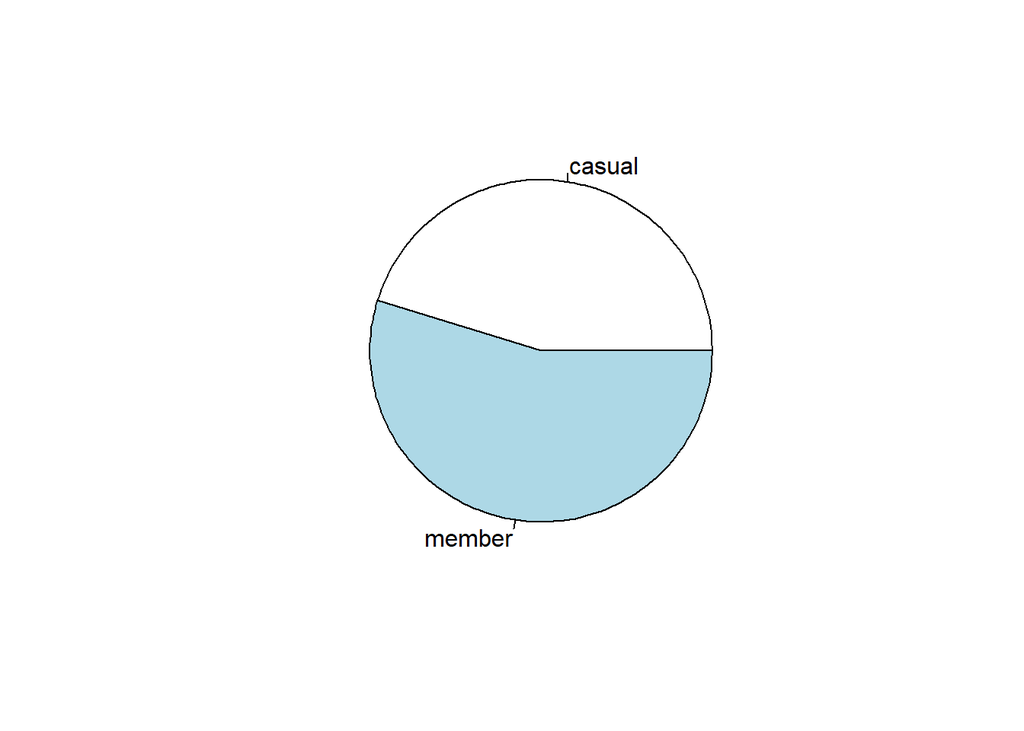

```r
pie(table(cyclistic_data_v2$user_type))
```

We want to have an handle of the `mean()`,`median()`, `max()` and `min()`*ride_length* for both user group. The code chunk below does that.

```r
mean(cyclistic_data_v2$ride_length)
```

```
## [1] 1316.299
```

```r
median(cyclistic_data_v2$ride_length)
```

```
## [1] 720
```

```r
max(cyclistic_data_v2$ride_length)
```

```
## [1] 3356649
```

```r
min(cyclistic_data_v2$ride_length)
```

```
## [1] 1
```

Then we look at the `mean()`,`median()`, `max()` and `min()` **ride_length** for each user group. The code chunk below does that.  
The `mean()` **ride_length** for **casual** riders is higher than that of **annual** members which means the casual riders on the average use the bike longer per ride. This can tend to mean that the casual riders use the bikes for leisure while the annual members use it more routinely probably to commute or for exercise and other things like that.

```r
aggregate(cyclistic_data_v2$ride_length ~ cyclistic_data_v2$user_type, FUN = mean)
```

```
##   cyclistic_data_v2$user_type cyclistic_data_v2$ride_length
## 1                      casual                     1920.3468
## 2                      member                      818.0727
```

```r
aggregate(cyclistic_data_v2$ride_length ~ cyclistic_data_v2$user_type, FUN = median)
```

```
##   cyclistic_data_v2$user_type cyclistic_data_v2$ride_length
## 1                      casual                           959
## 2                      member                           576
```

```r
aggregate(cyclistic_data_v2$ride_length ~ cyclistic_data_v2$user_type, FUN = max)
```

```
##   cyclistic_data_v2$user_type cyclistic_data_v2$ride_length
## 1                      casual                       3356649
## 2                      member                         93596
```

```r
aggregate(cyclistic_data_v2$ride_length ~ cyclistic_data_v2$user_type, FUN = min)
```

```
##   cyclistic_data_v2$user_type cyclistic_data_v2$ride_length
## 1                      casual                             1
## 2                      member                             1
```

We will look into the bike preference of each user group using the code chunk below.

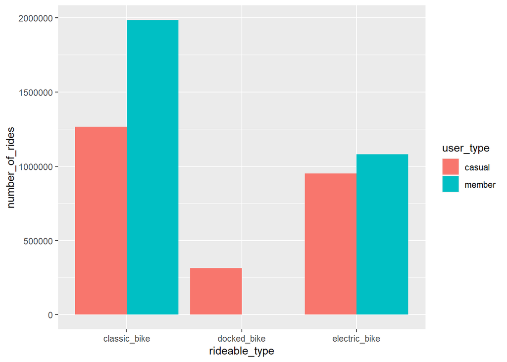

```r
cyclistic_data_v2 %>%
  group_by(user_type, rideable_type) %>%
  summarise(number_of_rides = n()) %>%
  arrange(user_type, rideable_type) %>%
  ggplot(aes(x = rideable_type, y = number_of_rides, fill = user_type)) +
  geom_col(position = "dodge")
```

With the average duration of the trip, we can discover which bike type was preferred by each user group using the code chunk below.

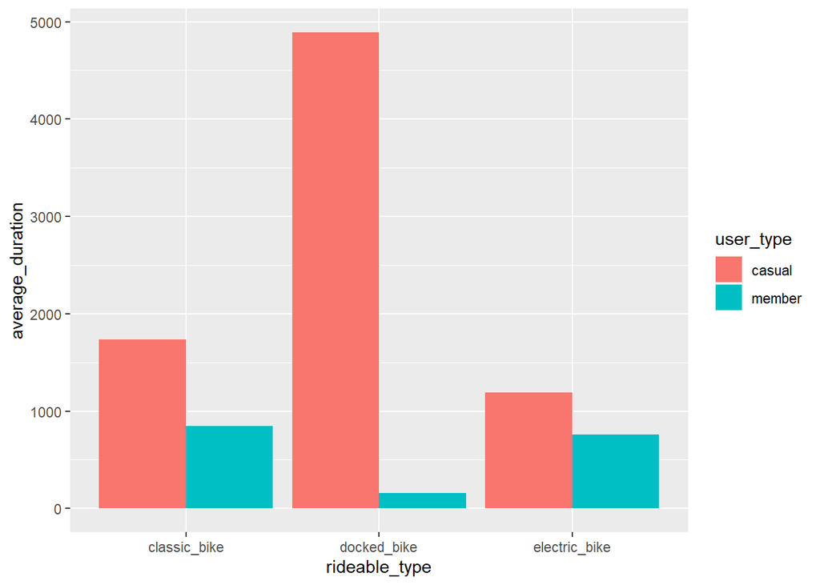

```r
cyclistic_data_v2 %>%
  group_by(user_type, rideable_type) %>%
  summarise(average_duration = mean(ride_length)) %>%
  arrange(user_type, rideable_type) %>%
  ggplot(aes(x = rideable_type, y = average_duration, fill = user_type)) +
  geom_col(position = "dodge")
```

Now, we want to get the average `ride_length` by `user_group` for each day of the week. The code chunk below does that.

```r
aggregate(cyclistic_data_v2$ride_length ~ cyclistic_data_v2$user_type + cyclistic_data_v2$day_of_week, FUN = mean)
```

```
##    cyclistic_data_v2$user_type cyclistic_data_v2$day_of_week
## 1                       casual                        Sunday
## 2                       member                        Sunday
## 3                       casual                        Monday
## 4                       member                        Monday
## 5                       casual                       Tuesday
## 6                       member                       Tuesday
## 7                       casual                     Wednesday
## 8                       member                     Wednesday
## 9                       casual                      Thursday
## 10                      member                      Thursday
## 11                      casual                        Friday
## 12                      member                        Friday
## 13                      casual                      Saturday
## 14                      member                      Saturday
##    cyclistic_data_v2$ride_length
## 1                      2254.2573
## 2                       939.5538
## 3                      1912.7473
## 4                       794.8956
## 5                      1678.5293
## 6                       767.3451
## 7                      1659.6644
## 8                       769.2124
## 9                      1662.3466
## 10                      766.6220
## 11                     1821.1061
## 12                      799.5648
## 13                     2082.5980
## 14                      915.9313
```

We will order the days of the week and months of the year so they will be in order in our plots. The code chunk below does that.

```r
cyclistic_data_v2$day_of_week <- ordered(cyclistic_data_v2$day_of_week, levels = c("Sunday", "Monday", "Tuesday", "Wednesday", "Thursday", "Friday", "Saturday"))
cyclistic_data_v2$month_of_year <- ordered(cyclistic_data_v2$month_of_year, levels = c("January", "February", "March", "April", "May", "June", "July", "August", "September", "October", "November", "December"))
```

Next, we will visualize the data in a bar chart using the code chunk below. This chart represents the `number_of_rides` by `user_group` for each day of the week.

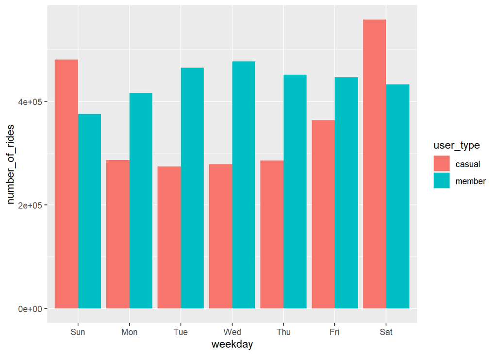

```r
cyclistic_data_v2 %>%
  mutate(weekday = wday(started_at, label = TRUE)) %>%
  group_by(user_type, weekday) %>%
  summarise(number_of_rides = n(), average_duration = mean(ride_length)) %>%
  arrange(user_type, weekday) %>%
  ggplot(aes(x = weekday, y = number_of_rides, fill = user_type)) +
  geom_col(position = "dodge")
```

This next visual represents the average `ride_length` by `user_group` for each day of the week.

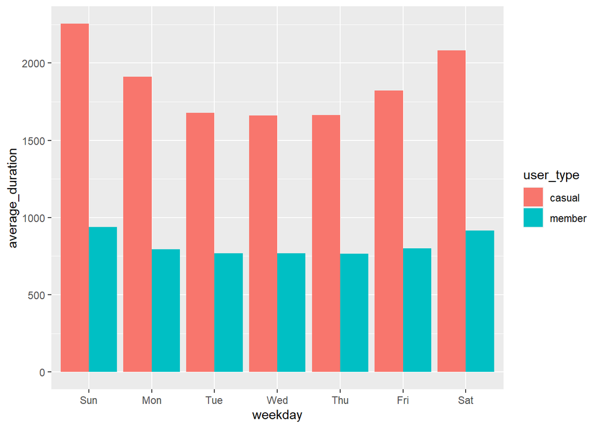

```r
cyclistic_data_v2 %>%
  mutate(weekday = wday(started_at, label = TRUE)) %>%
  group_by(user_type, weekday) %>%
  summarise(number_of_rides = n(), average_duration = mean(ride_length)) %>%
  arrange(user_type, weekday) %>%
  ggplot(aes(x = weekday, y = average_duration, fill = user_type)) +
  geom_col(position = "dodge")
```

To take it a step up, we will also make a visual for the `number_of_rides` by `user_group` for each month of the year using the code chunk below.

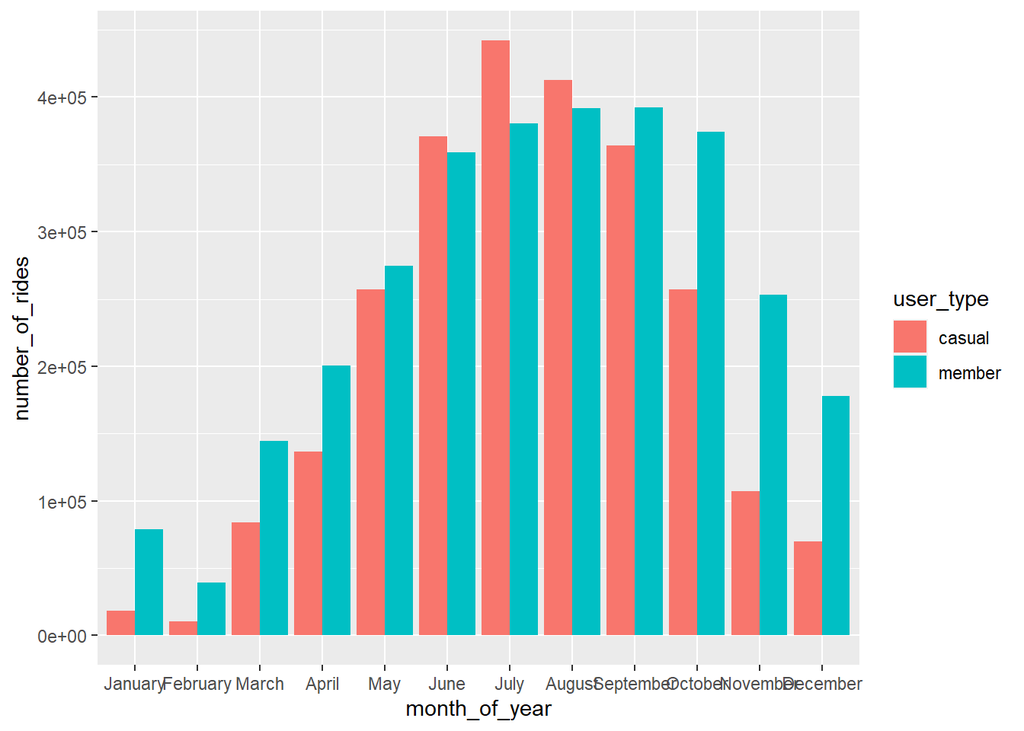

```r
cyclistic_data_v2 %>%
  mutate(month(started_at, label = TRUE)) %>%
  group_by(user_type, month_of_year) %>%
  summarise(number_of_rides = n(), average_duration = mean(ride_length)) %>%
  arrange(user_type, month_of_year) %>%
  ggplot(aes(x = month_of_year, y = number_of_rides, fill = user_type)) +
  geom_col(position = "dodge")
```

The last visual will be the visual for average `ride_length` by `user_group` for each month of the year.

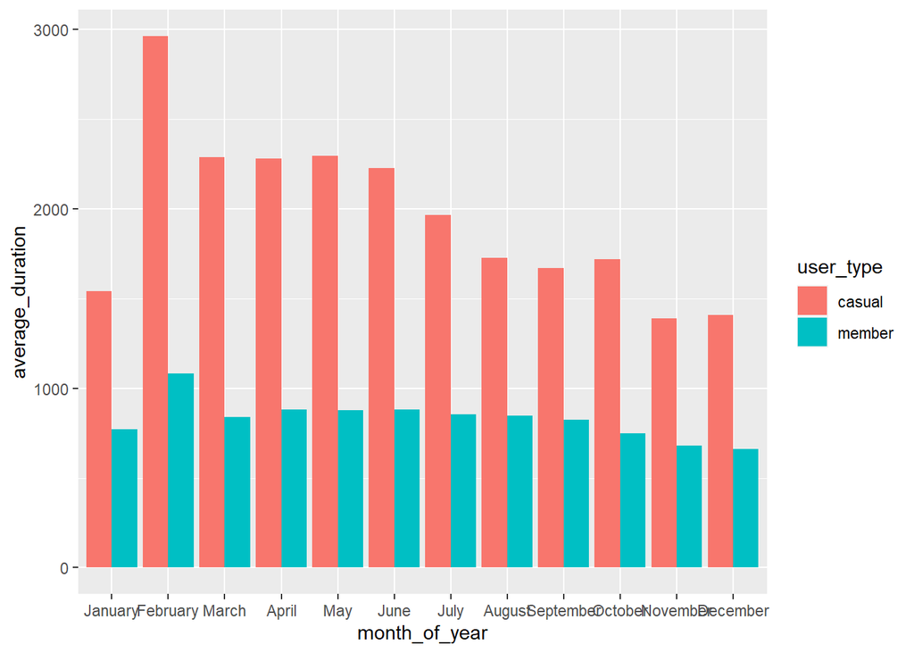

```r
cyclistic_data_v2 %>%
  mutate(month(started_at, label = TRUE)) %>%
  group_by(user_type, month_of_year) %>%
  summarise(number_of_rides = n(), average_duration = mean(ride_length)) %>%
  arrange(user_type, month_of_year) %>%
  ggplot(aes(x = month_of_year, y = average_duration, fill = user_type)) +
  geom_col(position = "dodge")
```

## Conclusion

### Findings

From the analysis, we discovered the following:  
* Annual members prefer to ride the classic and electric bike  
* Even though the number of users using docked bike is the smallest, they have the highest average ride time. This indicates that the users of the docked bike use it much longer than any of the other bike types.  
* The number of rides by day of the week for each user group shows that the casual riders use the bikes predominantly during the weekend which tends towards the assumption that they use it for leisure compared to the annual members whose usage of the bike is more evenly distributed all week long.  
* The same can be said for the average ride time for each user group with the average ride length evenly distributed for the annual members and is more during the weekend for the casual riders.  
* The number of rides for each user type for each month of the year does not really show much about the difference in usage from each user group, if anything, it only shows that bike usage is seasonal as the usage for both user group drops during winter.

### Recommendation

- With the findings i have made, i think i don’t have enough data to make definitive insight on the data.
- That being said, given the finding that there is a sizable number of casual users (they account for 45% of the total user type), the company can create a membership package to suit their need for leisure since we assumed that the casual riders predominantly use the bike for leisure. The company can organise riding competitions or riders club for those with membership cards.
- To better ascertain the difference in the usage of the bikes by each user group, more data will be needed to better understand each user group and how to better serve them.